# Servikal kanser verisinde sınıflandırma algoritmalarının kiyaslanması

Öğrenci: Fatih Ekici

Öğretim Görevlisi: Deniz İnan

27 Ocak 2021

Abstract

Bu döküman Doç.Dr. Deniz İnan tarafından verilen IST4034.1 kodlu Veri Madenciliği dersi finali için hazırlanmıştır. Veri kaynağı: [UCİ](https://archive.ics.uci.edu/ml/datasets/Cervical+cancer+%28Risk+Factors%29#)

# Veri hakkında temel bilgiler

Veri Venezuela, Caracas’taki ’Hospital Universitario da toplandı. Veri seti 858 hastanın demografik bilgilerini, alışkanlıklarını ve geçmiş tıbbi kayıtlarını içerir.Veri seti hastaların rahim ağzı kanseri var mı yok mu şeklinde bilgi içermekte hedef değişkenimiz ise biyopsi sonucu Bu sonuca göre hasta veya hasta değil bilgisine erişiyoruz.

## Veri künyesi

| veri tipi | değişken ismi | değişken açıklaması |
| --- | --- | --- |
| int | Age | Yaş |
| int | Number of sexual partners | Cinsel partner sayisi |
| int | First sexual intercourse | ilk cinsel ilişki |
| int | Num of pregnancies | gebelik sayisi |
| bool | Smokes | Sigara kullanıyor mu? |
| bool | Smokes (years) | Sigara kullaniyor ise kaç yıldır kullanıyor? |
| bool | Smokes (packs/year) | yıllık sigara paketi sayisi |
| bool | Hormonal Contraceptives | Hormonal Kontraseptifler |
| int | Hormonal Contraceptives (years) | Hormonal Kontraseptifler(Yıllık) |
| bool | IUD | Hormon salıcı kullanıyor mu? |
| int | IUD (years) | Yılda kaç adet IUD kullanıyor? |
| bool | STDs | Cinsel hastalığı var mı? |
| int | STDs (number) | Kaç adet cinsel hastalığı var |
| bool | STDs:condylomatosis | Hpv sebepli siğil |
| bool | STDs:cervical condylomatosis | Hpv sebepli rahim ağzı siğili |
| bool | STDs:vaginal condylomatosis | Vajinal bölge siğil |
| bool | STDs:vulvo-perineal condylomatosis | Dış genital bölge siğili |
| bool | STDs:syphilis | sifiliz |
| bool | STDs:pelvic inflammatory disease | pelvik inflamatuar hastalık |
| bool | STDs:genital herpes | genital herpes |
| bool | STDs:molluscum contagiosum | molluscum contagiosum |
| bool | STDs:AIDS | AIDS |
| bool | STDs:IHV | HiV |
| bool | STDs:Hepatitis B | Hepatitis B |
| bool | STDs:HPV | HPV |
| int | STDs: Number of diagnosis | Tanı sayısı |
| int | STDs: Time since first diagnosis | İlk teşhisten itibaren geçen süre |
| int | STDs: Time since last diagnosis | Son teşhisten bu yana geçen süre |
| bool | Dx:Cancer | Kanser |
| bool | Dx:CIN | CIN |
| bool | Dx:HPV | HPV |
| bool | Dx | Dx |
| bool | Hinselmann | Hinselmann |
| bool | Schiller | Schiller(test) |
| bool | Citology | Sitoloji(test) |
| bool | Biopsy | Biyopsi(test) |

# Veri analizine giriş

##Yüklenmesi gereken paketler**

**Paralel hesaplama**

```r
library(doParallel)
cl <- makePSOCKcluster(7)

registerDoParallel(cl)
```

**Verinin Yüklenmesi**

```r
cancer_df <- read_csv("Cervical_cancer_(Risk_Factors)/risk_factors_cervical_cancer.csv",
    na = "?")
cancer_df %>% top_n(10)
```

| Age | Number of sexual partners | First sexual intercourse | Num of pregnancies | Smokes | Smokes (years) | Smokes (packs/year) | Hormonal Contraceptives | Hormonal Contraceptives (years) | IUD | IUD (years) | STDs | STDs (number) | STDs:condylomatosis | STDs:cervical condylomatosis | STDs:vaginal condylomatosis | STDs:vulvo-perineal condylomatosis | STDs:syphilis | STDs:pelvic inflammatory disease | STDs:genital herpes | STDs:molluscum contagiosum | STDs:AIDS | STDs:HIV | STDs:Hepatitis B | STDs:HPV | STDs: Number of diagnosis | STDs: Time since first diagnosis | STDs: Time since last diagnosis | Dx:Cancer | Dx:CIN | … |
| --- | --- | --- | --- | --- | --- | --- | --- | --- | --- | --- | --- | --- | --- | --- | --- | --- | --- | --- | --- | --- | --- | --- | --- | --- | --- | --- | --- | --- | --- | --- |
| 51 | 3 | 17 | 6 | 1 | 34.000000 | 3.4000000 | 0 | 0.00 | 1 | 7 | 0 | 0 | 0 | 0 | 0 | 0 | 0 | 0 | 0 | 0 | 0 | 0 | 0 | 0 | 0 | NA | NA | 0 | 0 | … |
| 40 | 1 | 18 | 1 | 0 | 0.000000 | 0.0000000 | 1 | 0.25 | 0 | 0 | 1 | 2 | 1 | 0 | 0 | 1 | 0 | 0 | 0 | 0 | 0 | 0 | 0 | 0 | 1 | 2 | 2 | 0 | 0 | … |
| 40 | 1 | 20 | 2 | 0 | 0.000000 | 0.0000000 | 1 | 15.00 | 0 | 0 | 0 | 0 | 0 | 0 | 0 | 0 | 0 | 0 | 0 | 0 | 0 | 0 | 0 | 0 | 0 | NA | NA | 1 | 0 | … |
| 37 | 2 | 18 | NA | 0 | 0.000000 | 0.0000000 | 0 | 0.00 | NA | NA | 1 | 1 | 0 | 0 | 0 | 0 | 0 | 0 | 0 | 0 | 0 | 1 | 0 | 0 | 1 | 15 | 15 | 0 | 1 | … |
| 37 | 3 | 19 | 3 | 1 | 12.000000 | 6.0000000 | 1 | 13.00 | 0 | 0 | 0 | 0 | 0 | 0 | 0 | 0 | 0 | 0 | 0 | 0 | 0 | 0 | 0 | 0 | 0 | NA | NA | 0 | 0 | … |
| 38 | 2 | 15 | 4 | 0 | 0.000000 | 0.0000000 | 1 | 16.00 | 0 | 0 | 0 | 0 | 0 | 0 | 0 | 0 | 0 | 0 | 0 | 0 | 0 | 0 | 0 | 0 | 0 | NA | NA | 1 | 0 | … |
| 33 | 1 | 29 | 2 | 0 | 0.000000 | 0.0000000 | 1 | 0.50 | 0 | 0 | 0 | 0 | 0 | 0 | 0 | 0 | 0 | 0 | 0 | 0 | 0 | 0 | 0 | 0 | 0 | NA | NA | 0 | 0 | … |
| 35 | 5 | 11 | NA | 1 | 15.000000 | 15.0000000 | 1 | 14.00 | 0 | 0 | 0 | 0 | 0 | 0 | 0 | 0 | 0 | 0 | 0 | 0 | 0 | 0 | 0 | 0 | 0 | NA | NA | 0 | 0 | … |
| 38 | 3 | 18 | 4 | 0 | 0.000000 | 0.0000000 | 1 | 10.00 | 1 | 2 | 0 | 0 | 0 | 0 | 0 | 0 | 0 | 0 | 0 | 0 | 0 | 0 | 0 | 0 | 0 | NA | NA | 0 | 0 | … |
| 30 | NA | 13 | 3 | 1 | 22.000000 | 3.3000000 | 0 | 0.00 | 0 | 0 | 1 | 1 | 0 | 0 | 0 | 0 | 0 | 0 | 0 | 0 | 0 | 1 | 0 | 0 | 1 | 3 | 3 | 0 | 0 | … |

[output cut: 45 more lines]

Eksik veri sayımızı değişkenlerin temel istatistiklerini inceleyelim.

```r
#skimr paketi veriyi summary()'Ye kıyasla daha güzel bir format ile gösterir.

cancer_df %>% janitor::clean_names() %>% skimr::skim()->skim
skim
```

Data summary

| Name | Piped data |
| --- | --- |
| Number of rows | 858 |
| Number of columns | 36 |
| _______________________ |  |
| Column type frequency: |  |
| numeric | 36 |
| ________________________ |  |
| Group variables | None |

**Variable type: numeric**

| skim_variable | n_missing | complete_rate | mean | sd | p0 | p25 | p50 | p75 | p100 | hist |
| --- | --- | --- | --- | --- | --- | --- | --- | --- | --- | --- |
| age | 0 | 1.00 | 26.82 | 8.50 | 13 | 20 | 25.0 | 32.0 | 84 | ▇▅▁▁▁ |
| number_of_sexual_partners | 26 | 0.97 | 2.53 | 1.67 | 1 | 2 | 2.0 | 3.0 | 28 | ▇▁▁▁▁ |
| first_sexual_intercourse | 7 | 0.99 | 17.00 | 2.80 | 10 | 15 | 17.0 | 18.0 | 32 | ▂▇▂▁▁ |
| num_of_pregnancies | 56 | 0.93 | 2.28 | 1.45 | 0 | 1 | 2.0 | 3.0 | 11 | ▇▃▁▁▁ |
| smokes | 13 | 0.98 | 0.15 | 0.35 | 0 | 0 | 0.0 | 0.0 | 1 | ▇▁▁▁▂ |
| smokes_years | 13 | 0.98 | 1.22 | 4.09 | 0 | 0 | 0.0 | 0.0 | 37 | ▇▁▁▁▁ |
| smokes_packs_year | 13 | 0.98 | 0.45 | 2.23 | 0 | 0 | 0.0 | 0.0 | 37 | ▇▁▁▁▁ |
| hormonal_contraceptives | 108 | 0.87 | 0.64 | 0.48 | 0 | 0 | 1.0 | 1.0 | 1 | ▅▁▁▁▇ |
| hormonal_contraceptives_years | 108 | 0.87 | 2.26 | 3.76 | 0 | 0 | 0.5 | 3.0 | 30 | ▇▁▁▁▁ |
| iud | 117 | 0.86 | 0.11 | 0.32 | 0 | 0 | 0.0 | 0.0 | 1 | ▇▁▁▁▁ |
| iud_years | 117 | 0.86 | 0.51 | 1.94 | 0 | 0 | 0.0 | 0.0 | 19 | ▇▁▁▁▁ |
| st_ds | 105 | 0.88 | 0.10 | 0.31 | 0 | 0 | 0.0 | 0.0 | 1 | ▇▁▁▁▁ |
| st_ds_number | 105 | 0.88 | 0.18 | 0.56 | 0 | 0 | 0.0 | 0.0 | 4 | ▇▁▁▁▁ |
| st_ds_condylomatosis | 105 | 0.88 | 0.06 | 0.23 | 0 | 0 | 0.0 | 0.0 | 1 | ▇▁▁▁▁ |
| st_ds_cervical_condylomatosis | 105 | 0.88 | 0.00 | 0.00 | 0 | 0 | 0.0 | 0.0 | 0 | ▁▁▇▁▁ |
| st_ds_vaginal_condylomatosis | 105 | 0.88 | 0.01 | 0.07 | 0 | 0 | 0.0 | 0.0 | 1 | ▇▁▁▁▁ |
| st_ds_vulvo_perineal_condylomatosis | 105 | 0.88 | 0.06 | 0.23 | 0 | 0 | 0.0 | 0.0 | 1 | ▇▁▁▁▁ |
| st_ds_syphilis | 105 | 0.88 | 0.02 | 0.15 | 0 | 0 | 0.0 | 0.0 | 1 | ▇▁▁▁▁ |
| st_ds_pelvic_inflammatory_disease | 105 | 0.88 | 0.00 | 0.04 | 0 | 0 | 0.0 | 0.0 | 1 | ▇▁▁▁▁ |
| st_ds_genital_herpes | 105 | 0.88 | 0.00 | 0.04 | 0 | 0 | 0.0 | 0.0 | 1 | ▇▁▁▁▁ |
| st_ds_molluscum_contagiosum | 105 | 0.88 | 0.00 | 0.04 | 0 | 0 | 0.0 | 0.0 | 1 | ▇▁▁▁▁ |
| st_ds_aids | 105 | 0.88 | 0.00 | 0.00 | 0 | 0 | 0.0 | 0.0 | 0 | ▁▁▇▁▁ |
| st_ds_hiv | 105 | 0.88 | 0.02 | 0.15 | 0 | 0 | 0.0 | 0.0 | 1 | ▇▁▁▁▁ |
| st_ds_hepatitis_b | 105 | 0.88 | 0.00 | 0.04 | 0 | 0 | 0.0 | 0.0 | 1 | ▇▁▁▁▁ |
| st_ds_hpv | 105 | 0.88 | 0.00 | 0.05 | 0 | 0 | 0.0 | 0.0 | 1 | ▇▁▁▁▁ |
| st_ds_number_of_diagnosis | 0 | 1.00 | 0.09 | 0.30 | 0 | 0 | 0.0 | 0.0 | 3 | ▇▁▁▁▁ |
| st_ds_time_since_first_diagnosis | 787 | 0.08 | 6.14 | 5.90 | 1 | 2 | 4.0 | 8.0 | 22 | ▇▂▁▁▁ |
| st_ds_time_since_last_diagnosis | 787 | 0.08 | 5.82 | 5.76 | 1 | 2 | 3.0 | 7.5 | 22 | ▇▂▁▁▁ |
| dx_cancer | 0 | 1.00 | 0.02 | 0.14 | 0 | 0 | 0.0 | 0.0 | 1 | ▇▁▁▁▁ |
| dx_cin | 0 | 1.00 | 0.01 | 0.10 | 0 | 0 | 0.0 | 0.0 | 1 | ▇▁▁▁▁ |
| dx_hpv | 0 | 1.00 | 0.02 | 0.14 | 0 | 0 | 0.0 | 0.0 | 1 | ▇▁▁▁▁ |
| dx | 0 | 1.00 | 0.03 | 0.16 | 0 | 0 | 0.0 | 0.0 | 1 | ▇▁▁▁▁ |
| hinselmann | 0 | 1.00 | 0.04 | 0.20 | 0 | 0 | 0.0 | 0.0 | 1 | ▇▁▁▁▁ |
| schiller | 0 | 1.00 | 0.09 | 0.28 | 0 | 0 | 0.0 | 0.0 | 1 | ▇▁▁▁▁ |
| citology | 0 | 1.00 | 0.05 | 0.22 | 0 | 0 | 0.0 | 0.0 | 1 | ▇▁▁▁▁ |
| biopsy | 0 | 1.00 | 0.06 | 0.25 | 0 | 0 | 0.0 | 0.0 | 1 | ▇▁▁▁▁ |

## Eksik ve Hatalı gözlemlerin silinmesi.

```r
sum(is.na(cancer_df))
```

[1] 3622 Toplam 3622 adet eksik gözlem bulunmakta. Verideki eksik değişkenler gerçeken bilinmediği için değil herhangi bir değer girilmesinin anlamsız kalınmasından kaynaklı eksikler.STD’si bulunmayan bir kişinin ilk teşhis tarihi bulunmayacağından dolayı ilgili kısım boş kalakacaktır. Sonuç olarak eksik verileri yapacağımız modellerin gereksinimleri sebebiyle doldurmalıyız veya bazı gözlem veya değişkenleri silmeliyiz. Eksik gözlemleri araştıralım.

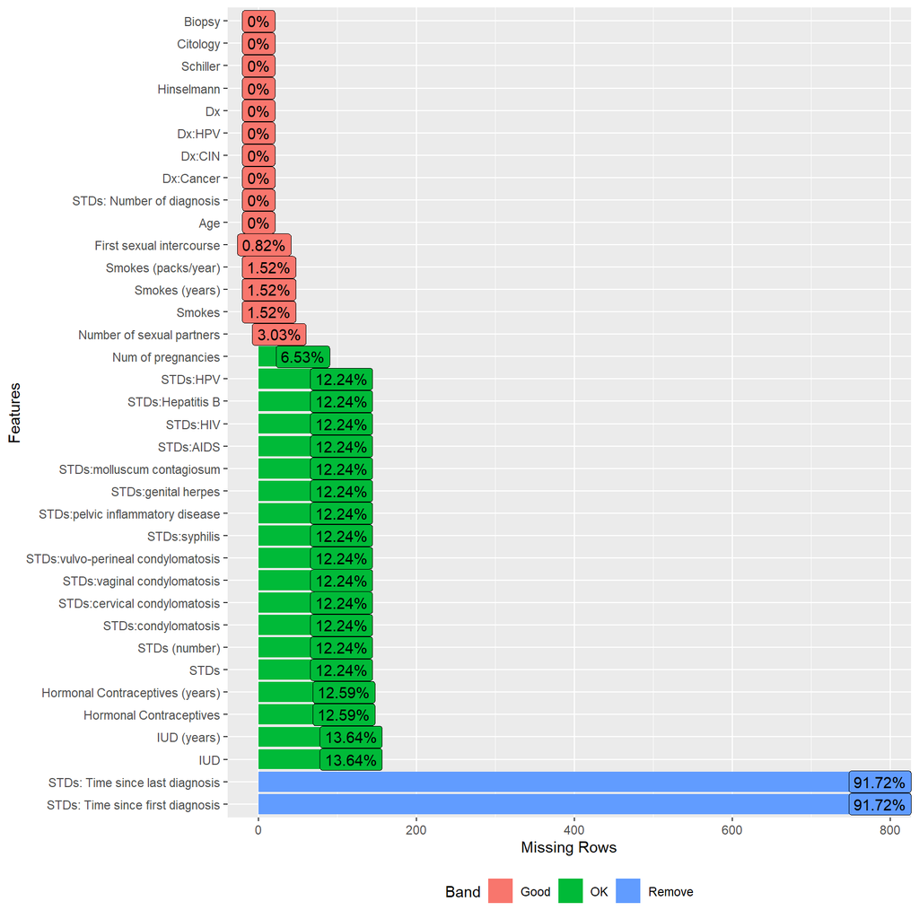

```r
DataExplorer::plot_missing(cancer_df)
```

En büyük problem STDs kısmında gözüküyor bakalım.

```r
cancer_df %>% filter(STDs!=0) %>% select(`STDs: Time since first diagnosis`,`STDs: Time since last diagnosis`) %>% nrow()-
  cancer_df %>% filter(STDs!=0) %>% select(`STDs: Time since first diagnosis`,`STDs: Time since last diagnosis`) %>%na.omit() %>%  nrow()
```

[1] 8 Cinsel hastalığı olan kişiler için sadece 8 kişinin teşhiş bilgisi tanımlanmamış Kalan herkesin bilgisi bulunmakta, Yani aslında eksik sayısı 8 diyebiliriz.

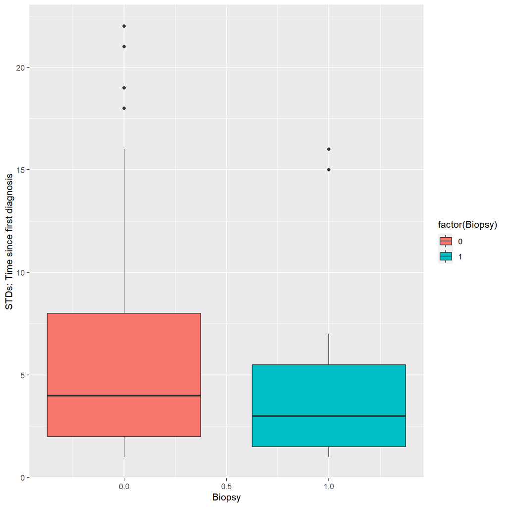

```r
#teşhis süresinden geçen zamanın biopsy sürecine olan etkisini bakalım.
cancer_df[c("STDs: Time since first diagnosis","STDs: Time since last diagnosis","Biopsy")] %>% ggplot(aes(y=`STDs: Time since first diagnosis`,x=`Biopsy`)) +geom_boxplot(aes(fill=factor(Biopsy)))
```

```r
cancer_df %>% group_by(`STDs: Time since first diagnosis`) %>% summarise(n=n())
```

|  | STDs: Time since first diagnosis | n |
| --- | --- | --- |
| 1 | 1 | 15 |
| 2 | 2 | 9 |
| 3 | 3 | 10 |
| 4 | 4 | 6 |
| 5 | 5 | 4 |
| 6 | 6 | 3 |
| 7 | 7 | 5 |
| 8 | 8 | 3 |
| 9 | 9 | 1 |
| 10 | 10 | 1 |

[output cut: 9 more lines]

Boxplot aykırı değerler sebebiyle pek net olmayan bir sonuç vermiştir. ilk 3 yılın toplam dolu gözlem sayısının yarısına yakın bir miktarına eşit olduğunu görmekteyiz.Açıkçası modele yüksek miktarda farkı olan bir değişken olmaması sebebiyle gruplara ayırıp NA’ları doldurmayı gereksiz buluyorum. Biopsi sonucuna asıl etki edenin gerekenin STD olup olmadığı veya kaç adet STD sahibi olduğudur. Bu sebeble bu değişkenleri silelim.

```r
cancer_df %>% select(-c("STDs: Time since first diagnosis","STDs: Time since last diagnosis"))->cancer_df
```

Ayrıca verideki smokes pacts/year değişkeni hatalı bilgi içermektedir. Bu sebeble bu değişkenide kaldıralım.

```r
cancer_df %>% select(-c(`Smokes (packs/year)`))->cancer_df
cancer_df %>% mutate(`Smokes (years)`=round(`Smokes (years)`),
                     `Hormonal Contraceptives (years)`=round(`Hormonal Contraceptives (years)`,2))->cancer_df
```

```r
#binary fonksiyonu
is.binary<-function(x){
  return(ifelse((na.omit(x) %>% unique() %>% length())<3,TRUE,FALSE))
}
#dönüştürme fonksiyonu
cancer_df %>%  mutate_if(is.binary,as.factor)->cancer_df

cancer_df<-na.omit(cancer_df)
cancer_df$`STDs:cervical condylomatosis`<-as.numeric(cancer_df$`STDs:cervical condylomatosis`)
cancer_df$`STDs:AIDS`<-as.numeric(cancer_df$`STDs:AIDS`)
```

## Dengesiz dağılmış veri problemi

```r
cancer_df %>% select(Biopsy) %>% group_by(Biopsy) %>% summarise(n=n())
```

|  | Biopsy | n |
| --- | --- | --- |
| 1 | 0 | 623 |
| 2 | 1 | 45 |

Verimizde 623 adet biyopsi sonucu 0 çıkan hasta var iken 45 adet 1(pozitif) çıkan hasta bu durumda sınıflandırma dengesiz gözlem problemi ile karşılaşıyoruz. Burda yapabileceğimiz şeyler metriklerimizi kappa ve auc alarak devam etmek ,undersampling yapmak, veya smote ile sentetik yeni gözlemler oluşturarak verimizi çoğaltmaktır.

# Train-test ayrımı

```r
set.seed(5)
split = sample.split(cancer_df$Biopsy, SplitRatio = 0.50)

train = subset(cancer_df,split == TRUE)
colnames(train)<-make.names(colnames(train))
test = subset(cancer_df,split == FALSE)
colnames(test)<-make.names(colnames(test))
train %>% select(-c( STDs.pelvic.inflammatory.disease,STDs.cervical.condylomatosis,STDs.AIDS, STDs.Hepatitis.B))->train
```

# Model oluşturma

Burada pek çok model oluşturup bu modelleri test edeceğiz. burada bagging ile başlayıp veriyi sanallaştırıp performansı test edeceğim iyi sonuç verirse diğer modellerde de simüle veri kullanacaktır.

## Bagging modeli

Mtry değeri bağımsız değişken sayısına eşitlediğimizde bagging yapmamıza olanak sağlıyor.

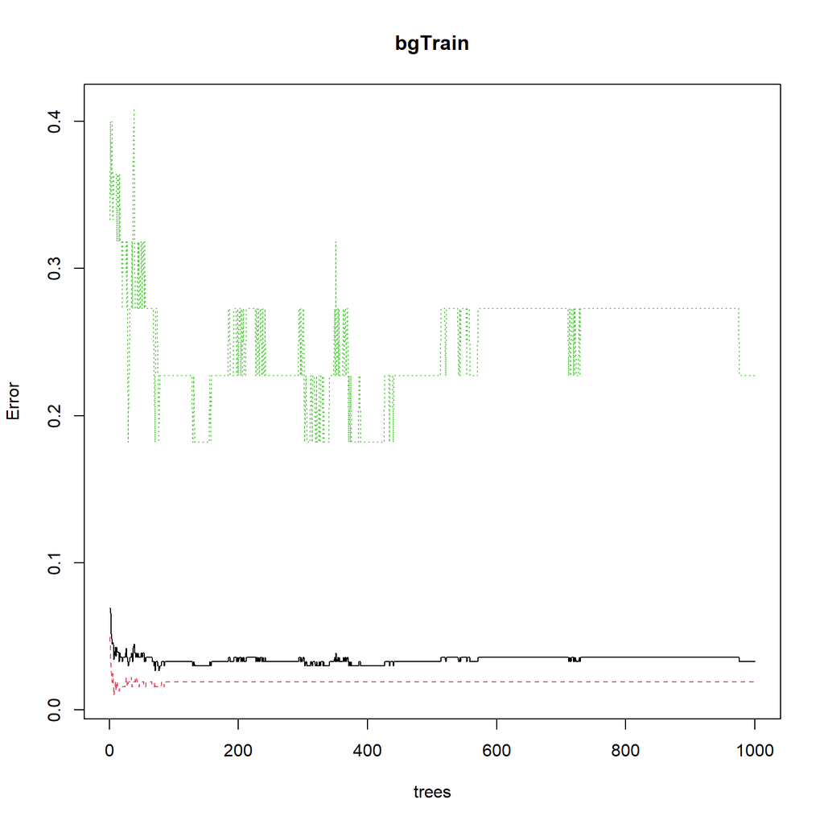

```r
set.seed(6)
bgTrain<-randomForest(Biopsy~.,data = train,
                      importance=TRUE,
                      mtry=ncol(train)-1,
                      ntree=1000,
                      metric="ROC"
                       )
plot(bgTrain)
```

```r
library(caret)
library(randomForest)
set.seed(99)
confusionMatrixBagging<-confusionMatrix(predict(bgTrain,test),test$Biopsy,positive = "1")
confusionMatrixBagging
```

Confusion Matrix and Statistics

```
      Reference
```

Prediction 0 1 0 300 9 1 11 14

```
           Accuracy : 0.9401
             95% CI : (0.909, 0.963)
No Information Rate : 0.9311
P-Value [Acc > NIR] : 0.3023

              Kappa : 0.5511
```

Mcnemar’s Test P-Value : 0.8231

```
        Sensitivity : 0.60870
        Specificity : 0.96463
     Pos Pred Value : 0.56000
     Neg Pred Value : 0.97087
         Prevalence : 0.06886
     Detection Rate : 0.04192
```

Detection Prevalence : 0.07485  
Balanced Accuracy : 0.78666

```
   'Positive' Class : 1
```

```r
confusionMatrixBagging$byClass %>% t() %>% magrittr::set_rownames('Bagging')-> resultBagging #sonuçları kıyaslamak için

print(data.frame(resultBagging))
```

```
    Sensitivity Specificity Pos.Pred.Value Neg.Pred.Value Precision
```

Bagging 0.6086957 0.9646302 0.56 0.9708738 0.56 Recall F1 Prevalence Detection.Rate Detection.Prevalence Bagging 0.6086957 0.5833333 0.06886228 0.04191617 0.0748503 Balanced.Accuracy Bagging 0.7866629

Oversampling ile daha iyi bir sonuç almayı deniyelim.

### Oversampling

Rose paketi ile oversampling yapıyorum.

```r
library(ROSE)
set.seed(100)
ovun.sample(Biopsy~., data=train,method = "over",N=624)$data->overtrain #N üretilmek istenen düsük gözlemin sayısı iki katını vererek eşit sayısa getiriyoruz.
rfOVerTrain<-randomForest(Biopsy~.,data = train,
                      importance=TRUE,
                      mtry=ncol(train)-1
                       )
table(overtrain$Biopsy)
```

0 1 312 312

```r
confusionMatrix(predict(rfOVerTrain,test),test$Biopsy,positive = "1")
```

Confusion Matrix and Statistics

```
      Reference
```

Prediction 0 1 0 300 9 1 11 14

```
           Accuracy : 0.9401
             95% CI : (0.909, 0.963)
No Information Rate : 0.9311
P-Value [Acc > NIR] : 0.3023

              Kappa : 0.5511
```

Mcnemar’s Test P-Value : 0.8231

```
        Sensitivity : 0.60870
        Specificity : 0.96463
     Pos Pred Value : 0.56000
     Neg Pred Value : 0.97087
         Prevalence : 0.06886
     Detection Rate : 0.04192
```

Detection Prevalence : 0.07485  
Balanced Accuracy : 0.78666

```
   'Positive' Class : 1
```

Model gayet mantıklı sonuçlar vermesi sebebiyle Tune işlemi yapmıyorum.

### Model iyileştirme

```r
#hedef değişkenin levelleri numeric olmamak zoruda bu sebeble veriyi yeniliyoruz.
train->train2
train2$Biopsy<-ifelse(train2$Biopsy==1,"YES","NO")
test->test2
test2$Biopsy<-ifelse(test2$Biopsy==1,"YES","NO")
test2$Biopsy<-as.factor(test2$Biopsy)
```

```r
#tekrarlı cross validasyon 10 fold 3 tekrar


control <- trainControl(method='repeatedcv',
                        number=10,
                        repeats=3,
                        search = 'random')
```

```r
train2$Biopsy<-as.factor(train2$Biopsy)
set.seed(170)
train
```

| Age | Number.of.sexual.partners | First.sexual.intercourse | Num.of.pregnancies | Smokes | Smokes..years. | Hormonal.Contraceptives | Hormonal.Contraceptives..years. | IUD | IUD..years. | STDs | STDs..number. | STDs.condylomatosis | STDs.vaginal.condylomatosis | STDs.vulvo.perineal.condylomatosis | STDs.syphilis | STDs.genital.herpes | STDs.molluscum.contagiosum | STDs.HIV | STDs.HPV | STDs..Number.of.diagnosis | Dx.Cancer | Dx.CIN | Dx.HPV | Dx | Hinselmann | Schiller | Citology | Biopsy |
| --- | --- | --- | --- | --- | --- | --- | --- | --- | --- | --- | --- | --- | --- | --- | --- | --- | --- | --- | --- | --- | --- | --- | --- | --- | --- | --- | --- | --- |
| 18 | 4 | 15 | 1 | 0 | 0 | 0 | 0.00 | 0 | 0.00 | 0 | 0 | 0 | 0 | 0 | 0 | 0 | 0 | 0 | 0 | 0 | 0 | 0 | 0 | 0 | 0 | 0 | 0 | 0 |
| 46 | 3 | 21 | 4 | 0 | 0 | 1 | 15.00 | 0 | 0.00 | 0 | 0 | 0 | 0 | 0 | 0 | 0 | 0 | 0 | 0 | 0 | 0 | 0 | 0 | 0 | 0 | 0 | 0 | 0 |
| 42 | 3 | 23 | 2 | 0 | 0 | 0 | 0.00 | 0 | 0.00 | 0 | 0 | 0 | 0 | 0 | 0 | 0 | 0 | 0 | 0 | 0 | 0 | 0 | 0 | 0 | 0 | 0 | 0 | 0 |
| 51 | 3 | 17 | 6 | 1 | 34 | 0 | 0.00 | 1 | 7.00 | 0 | 0 | 0 | 0 | 0 | 0 | 0 | 0 | 0 | 0 | 0 | 0 | 0 | 0 | 0 | 1 | 1 | 0 | 1 |
| 45 | 4 | 14 | 6 | 0 | 0 | 1 | 10.00 | 1 | 5.00 | 0 | 0 | 0 | 0 | 0 | 0 | 0 | 0 | 0 | 0 | 0 | 0 | 0 | 0 | 0 | 0 | 0 | 0 | 0 |
| 44 | 2 | 25 | 2 | 0 | 0 | 1 | 5.00 | 0 | 0.00 | 0 | 0 | 0 | 0 | 0 | 0 | 0 | 0 | 0 | 0 | 0 | 0 | 0 | 0 | 0 | 0 | 0 | 0 | 0 |
| 40 | 3 | 18 | 2 | 0 | 0 | 1 | 15.00 | 0 | 0.00 | 0 | 0 | 0 | 0 | 0 | 0 | 0 | 0 | 0 | 0 | 0 | 0 | 0 | 0 | 0 | 0 | 0 | 0 | 0 |
| 43 | 3 | 15 | 8 | 0 | 0 | 1 | 3.00 | 0 | 0.00 | 0 | 0 | 0 | 0 | 0 | 0 | 0 | 0 | 0 | 0 | 0 | 0 | 0 | 0 | 0 | 0 | 0 | 0 | 0 |
| 43 | 2 | 18 | 4 | 0 | 0 | 1 | 15.00 | 0 | 0.00 | 0 | 0 | 0 | 0 | 0 | 0 | 0 | 0 | 0 | 0 | 0 | 0 | 0 | 0 | 0 | 0 | 0 | 0 | 0 |
| 41 | 3 | 17 | 4 | 0 | 0 | 1 | 10.00 | 0 | 0.00 | 1 | 1 | 0 | 0 | 0 | 1 | 0 | 0 | 0 | 0 | 1 | 0 | 0 | 0 | 0 | 0 | 0 | 0 | 0 |

[output cut: 324 more lines]

```r
modelcv<-caret::train(
  Biopsy ~ .,
  data = train2,
  method = "treebag",
  trControl = control,
  nbagg = 200,
  control = rpart.control(minsplit = 2, cp = 0)
)
```

```r
#confussion matrix yazarak model performansını test edelim.
test_x<-select(test2,-Biopsy)
confusionMatrixBaggingTune<-confusionMatrix(predict(modelcv,test2),test2$Biopsy,positive="YES")

confusionMatrixBaggingTune$byClass %>%
  t() %>%
  magrittr::set_rownames('resultBaggingTune')-> resultBaggingTune#sonuçları kıyaslamak için

print(confusionMatrixBaggingTune)
```

Confusion Matrix and Statistics

```
      Reference
```

Prediction NO YES NO 301 9 YES 10 14

```
           Accuracy : 0.9431
             95% CI : (0.9126, 0.9654)
No Information Rate : 0.9311
P-Value [Acc > NIR] : 0.2287

              Kappa : 0.5652
```

Mcnemar’s Test P-Value : 1.0000

```
        Sensitivity : 0.60870
        Specificity : 0.96785
     Pos Pred Value : 0.58333
     Neg Pred Value : 0.97097
         Prevalence : 0.06886
     Detection Rate : 0.04192
```

Detection Prevalence : 0.07186  
Balanced Accuracy : 0.78827

```
   'Positive' Class : YES
```

```r
print(resultBaggingTune)
```

[output not shown]

## Klasik Karar Ağacı(Decision Tree)

Klasik karar ağacı modeli için rpart paketini kullanalım.

```r
 tcTrain<-rpart(formula=Biopsy~., data=train2, control=rpart.control(minsplit=2, minbucket=1, cp=0.001))
print(tcTrain)
```

n= 334

node), split, n, loss, yval, (yprob) * denotes terminal node

1. root 334 22 NO (0.934131737 0.065868263)  
   2) Schiller=0 306 2 NO (0.993464052 0.006535948)
   4. STDs.genital.herpes=0 305 1 NO (0.996721311 0.003278689)
   5. Dx.CIN=0 302 0 NO (1.000000000 0.000000000) *
   6. Dx.CIN=1 3 1 NO (0.666666667 0.333333333)  
      18) Age>=23 2 0 NO (1.000000000 0.000000000) *19) Age< 23 1 0 YES (0.000000000 1.000000000)*
   7. STDs.genital.herpes=1 1 0 YES (0.000000000 1.000000000) *
      3. Schiller=1 28 8 YES (0.285714286 0.714285714)
   8. Age< 17 2 0 NO (1.000000000 0.000000000) *
   9. Age>=17 26 6 YES (0.230769231 0.769230769)
   10. Age>=68 1 0 NO (1.000000000 0.000000000) *
   11. Age< 68 25 5 YES (0.200000000 0.800000000)  
       30) Age< 26.5 11 4 YES (0.363636364 0.636363636)
       60. Hormonal.Contraceptives..years.>=3.5 2 0 NO (1.000000000 0.000000000) *
       61. Hormonal.Contraceptives..years.< 3.5 9 2 YES (0.222222222 0.777777778)
       62. Smokes..years.>=4.5 1 0 NO (1.000000000 0.000000000) *
       63. Smokes..years.< 4.5 8 1 YES (0.125000000 0.875000000)
       64. Age< 21.5 3 1 YES (0.333333333 0.666666667)  
           492) First.sexual.intercourse>=16.5 1 0 NO (1.000000000 0.000000000) *493) First.sexual.intercourse< 16.5 2 0 YES (0.000000000 1.000000000)*
       65. Age>=21.5 5 0 YES (0.000000000 1.000000000) * 31) Age>=26.5 14 1 YES (0.071428571 0.928571429)
       66. Age>=38.5 4 1 YES (0.250000000 0.750000000)
       67. Age< 39.5 1 0 NO (1.000000000 0.000000000) *
       68. Age>=39.5 3 0 YES (0.000000000 1.000000000) *
       69. Age< 38.5 10 0 YES (0.000000000 1.000000000) * Basitçe modelimizi bu şekilde oluşturabiliyoruz.

```r
set.seed(102)
confusionMatrixTc<-confusionMatrix(predict(tcTrain,test2,type = "class"),test2$Biopsy,positive = "YES")

confusionMatrixTc$byClass %>% t() %>% magrittr::set_rownames('Decion Tree Clasic')-> resultTc #sonuçları kıyaslamak için
confusionMatrixTc
```

Confusion Matrix and Statistics

```
      Reference
```

Prediction NO YES NO 298 8 YES 13 15

```
           Accuracy : 0.9371
             95% CI : (0.9055, 0.9607)
No Information Rate : 0.9311
P-Value [Acc > NIR] : 0.3837

              Kappa : 0.5546
```

Mcnemar’s Test P-Value : 0.3827

```
        Sensitivity : 0.65217
        Specificity : 0.95820
     Pos Pred Value : 0.53571
     Neg Pred Value : 0.97386
         Prevalence : 0.06886
     Detection Rate : 0.04491
```

Detection Prevalence : 0.08383  
Balanced Accuracy : 0.80519

```
   'Positive' Class : YES
```

```r
resultTc
```

```
               Sensitivity Specificity Pos Pred Value Neg Pred Value
```

Decion Tree Clasic 0.6521739 0.9581994 0.5357143 0.9738562 Precision Recall F1 Prevalence Detection Rate Decion Tree Clasic 0.5357143 0.6521739 0.5882353 0.06886228 0.04491018 Detection Prevalence Balanced Accuracy Decion Tree Clasic 0.08383234 0.8051866

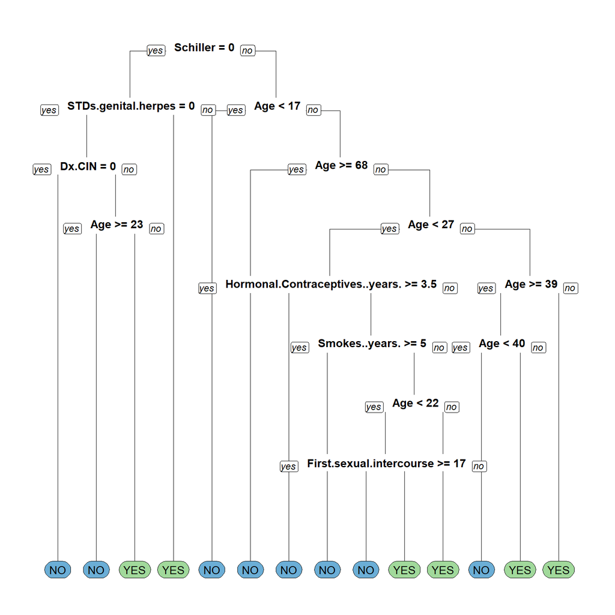

```r
rpart.plot::rpart.plot(x = tcTrain, yesno = 2, type = 0, extra = 0)
```

## Karar ağacı modelini budayalım.

rpart paketi default ayarlarda en sade modeli oluşturacak şekilde ayarlanmıştır. Herhangi bir kompleksite parametresi girmeden verinin budanmış halini alabiliriz.

```r
tcTrainSimple<-rpart(formula = Biopsy~.,data = train,
               method = "class")

print(tcTrainSimple)
```

n= 334

node), split, n, loss, yval, (yprob) * denotes terminal node

1. root 334 22 0 (0.934131737 0.065868263)
2. Schiller=0 306 2 0 (0.993464052 0.006535948) *
3. Schiller=1 28 8 1 (0.285714286 0.714285714) * GÖrüldüğü üzere tek bir adet ağaca düştük.

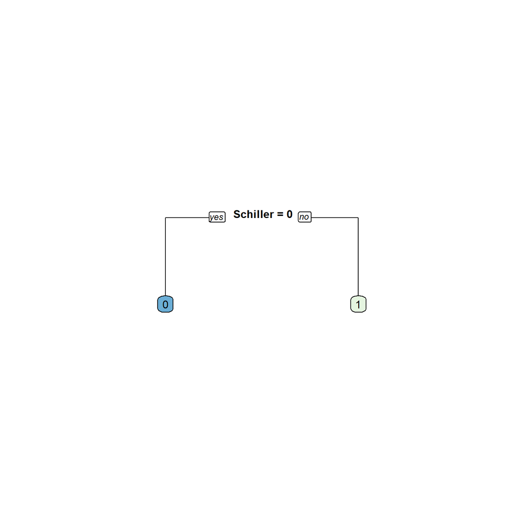

```r
rpart.plot::rpart.plot(x = tcTrainSimple, yesno = 2, type = 0, extra = 0)
```

Mudanmış modelimiz hazır.

Model performasını inceleyelim.

```r
set.seed(107)
confusionMatrixTcsimple<-
  confusionMatrix(factor(predict(tcTrainSimple,test,type = "class")),factor(test$Biopsy),positive = "1")

confusionMatrixTcsimple$byClass %>% t() %>% magrittr::set_rownames('Simple Decion Tree Clasic')-> resultSimpleTc #sonuçları kıyaslamak için
confusionMatrixTcsimple
```

Confusion Matrix and Statistics

```
      Reference
```

Prediction 0 1 0 296 3 1 15 20

```
           Accuracy : 0.9461
             95% CI : (0.9162, 0.9678)
No Information Rate : 0.9311
P-Value [Acc > NIR] : 0.165541

              Kappa : 0.6615
```

Mcnemar’s Test P-Value : 0.009522

```
        Sensitivity : 0.86957
        Specificity : 0.95177
     Pos Pred Value : 0.57143
     Neg Pred Value : 0.98997
         Prevalence : 0.06886
     Detection Rate : 0.05988
```

Detection Prevalence : 0.10479  
Balanced Accuracy : 0.91067

```
   'Positive' Class : 1
```

Etkili bir Sensitivity sonucu aldğımız kesinlikle aşikar, bu durum schiller testinin biopsi sonuca yüksek etki etmesinden kaynaklanıyor.

## Random Forest

Daha önceden oluşturmuş olduğumuz bagging modelinde mtry değerini karekök olarak aldığımızda random forest modeli oluşmakta modelimizi oluşturalım.

```r
rfTrain<-randomForest(Biopsy~.,data = train,
                      importance=TRUE,
                      mtry=sqrt(ncol(train))
                       )
confusionMatrixRandomForest<-confusionMatrix(predict(rfTrain,test),test$Biopsy,positive = "1")

confusionMatrixRandomForest$byClass %>%
  t() %>%
  magrittr::set_rownames('RandomForest')-> resultRandomForest #sonuçları kıyaslamak için

print(confusionMatrixRandomForest)
```

Confusion Matrix and Statistics

```
      Reference
```

Prediction 0 1 0 303 8 1 8 15

```
           Accuracy : 0.9521
             95% CI : (0.9234, 0.9724)
No Information Rate : 0.9311
P-Value [Acc > NIR] : 0.07474

              Kappa : 0.6265
```

Mcnemar’s Test P-Value : 1.00000

```
        Sensitivity : 0.65217
        Specificity : 0.97428
     Pos Pred Value : 0.65217
     Neg Pred Value : 0.97428
         Prevalence : 0.06886
     Detection Rate : 0.04491
```

Detection Prevalence : 0.06886  
Balanced Accuracy : 0.81323

```
   'Positive' Class : 1
```

```r
print(data.frame(resultRandomForest))
```

```
         Sensitivity Specificity Pos.Pred.Value Neg.Pred.Value Precision
```

RandomForest 0.6521739 0.9742765 0.6521739 0.9742765 0.6521739 Recall F1 Prevalence Detection.Rate Detection.Prevalence RandomForest 0.6521739 0.6521739 0.06886228 0.04491018 0.06886228 Balanced.Accuracy RandomForest 0.8132252

Random forest modelini Caret paketi ile hiper parametre iyileştirmesi yapalım. Caret sunduğu train() fonksiyonu ile grid veya random search yapmamıza imkan verir. Bu şekilde sensitivity puanımızı daha yüksek bulabliriz.

### model iyileştirme

```r
#hedef değişkenin levelleri numeric olmamak zoruda bu sebeble veriyi yeniliyoruz.
train->train2
train2$Biopsy<-ifelse(train2$Biopsy==1,"YES","NO")
test->test2
test2$Biopsy<-ifelse(test2$Biopsy==1,"YES","NO")
test2$Biopsy<-as.factor(test2$Biopsy)
```

```r
#tekrarlı cross validasyon 10 fold 3 tekrar

control <- trainControl(method='repeatedcv',
                        number=10,
                        repeats=3,
                        search = 'grid',
                        classProbs = TRUE)

set.seed(123)
#metriğimiz hata yapmayı cezalandıran "Roc" metriğini kullanacağız.
modelcv<-train(Biopsy~.,data = train2,
               methods="rf",
               metric="ROC",
               tuneLength  = 25,
               trControl=control)
```

```r
#confussion matrix yazarak model performansını test edelim.
test_x<-select(test2,-Biopsy)
confusionMatrixRandomForest<-confusionMatrix(predict(modelcv,test2),test2$Biopsy,positive="YES")

confusionMatrixRandomForest$byClass %>%
  t() %>%
  magrittr::set_rownames('RandomForest')-> resultRandomForest #sonuçları kıyaslamak için
```

```r
#sonuçların gösterilmesi
print(confusionMatrixRandomForest)
```

Confusion Matrix and Statistics

```
      Reference
```

Prediction NO YES NO 299 7 YES 12 16

```
           Accuracy : 0.9431
             95% CI : (0.9126, 0.9654)
No Information Rate : 0.9311
P-Value [Acc > NIR] : 0.2287

              Kappa : 0.597
```

Mcnemar’s Test P-Value : 0.3588

```
        Sensitivity : 0.69565
        Specificity : 0.96141
     Pos Pred Value : 0.57143
     Neg Pred Value : 0.97712
         Prevalence : 0.06886
     Detection Rate : 0.04790
```

Detection Prevalence : 0.08383  
Balanced Accuracy : 0.82853

```
   'Positive' Class : YES
```

```r
print(data.frame(resultRandomForest))
```

```
         Sensitivity Specificity Pos.Pred.Value Neg.Pred.Value Precision
```

RandomForest 0.6956522 0.9614148 0.5714286 0.9771242 0.5714286 Recall F1 Prevalence Detection.Rate Detection.Prevalence RandomForest 0.6956522 0.627451 0.06886228 0.04790419 0.08383234 Balanced.Accuracy RandomForest 0.8285335

## Boosting

Boosting modeli

Boosting modeli hedef değişkenin 0-1 formatında olmasını istiyor factorden integer’a çevirelim.

```r
train$Biopsy<-as.integer(train$Biopsy)
ifelse(train2$Biopsy=="NO",0,1)->train$Biopsy
test$Biopsy<-as.integer(test$Biopsy)
ifelse(test2$Biopsy=="NO",0,1)->test$Biopsy
```

**Modeli oluşturalım.**

```r
library(gbm)
set.seed(1453)
gmb_train<-gbm(Biopsy~.,data=train,
               shrinkage = 0.01, #adım büyüklüğü ne kadar küçükse o kadar iyi ve fazla zaman
               distribution = "bernoulli",#sınıflandırma
               cv.folds = 5, #cross validasyon
               n.trees = 3000, #ağaç sayısı
               verbose = F
               )
```

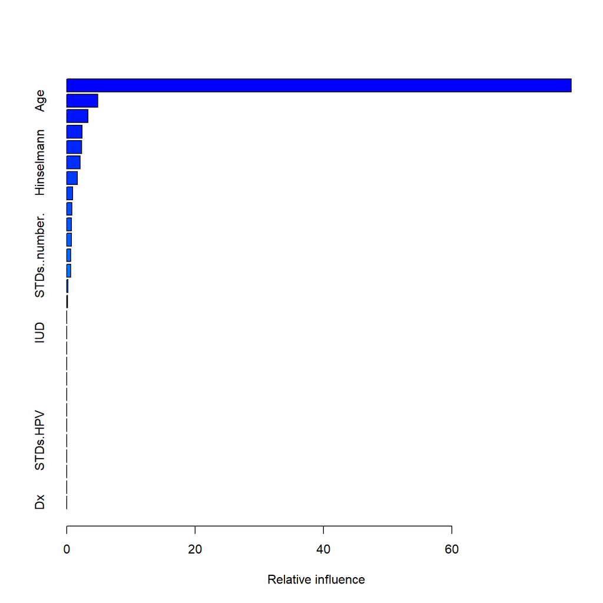

|  | var | rel.inf |
| --- | --- | --- |
| Schiller | Schiller | 78.5860576 |
| Age | Age | 4.8443406 |
| Smokes..years. | Smokes..years. | 3.3429996 |
| Hormonal.Contraceptives..years. | Hormonal.Contraceptives..years. | 2.3776471 |
| STDs..Number.of.diagnosis | STDs..Number.of.diagnosis | 2.3407355 |
| Hinselmann | Hinselmann | 2.0769604 |
| First.sexual.intercourse | First.sexual.intercourse | 1.6663560 |
| STDs | STDs | 0.9367756 |
| IUD..years. | IUD..years. | 0.8285665 |
| Citology | Citology | 0.7228068 |

[output cut: 18 more lines]

```r
summary(gmb_train)
```

Daha önceden belittiğimiz üzere Schiller testi biopsi sonucu için ana etmen bu sebeble aslında modellerin çoğu bu değişken sebebiyle domine olmakta.

Model performasını inceleyelim.

```r
pred <- predict(gmb_train,newdata=test,
                              type = "response")
ifelse(pred>0.5,1,0)->pred
```

### Confussion Matrix

```r
confusionMatrixGBM<-confusionMatrix(factor(pred),factor(test$Biopsy),positive="1")

confusionMatrixGBM$byClass %>%
  t() %>%
  magrittr::set_rownames('GBM')-> resultGBM #sonuçları kıyaslamak için

confusionMatrixGBM
```

Confusion Matrix and Statistics

```
      Reference
```

Prediction 0 1 0 296 3 1 15 20

```
           Accuracy : 0.9461
             95% CI : (0.9162, 0.9678)
No Information Rate : 0.9311
P-Value [Acc > NIR] : 0.165541

              Kappa : 0.6615
```

Mcnemar’s Test P-Value : 0.009522

```
        Sensitivity : 0.86957
        Specificity : 0.95177
     Pos Pred Value : 0.57143
     Neg Pred Value : 0.98997
         Prevalence : 0.06886
     Detection Rate : 0.05988
```

Detection Prevalence : 0.10479  
Balanced Accuracy : 0.91067

```
   'Positive' Class : 1
```

## Lojistik regresyon

Yine Gbm ile lojistik regresyon modeli yapacağız.

```r
logTrain <- glm(formula=Biopsy ~ . , family = binomial(link='logit'),data = train)
```

```r
predGBM <- predict(logTrain,newdata=select(test,-Biopsy),type='response')

# Bu mdoel de olasılık çıktısı verdiği için dönüşüm yapıyoruz
predGBM<- ifelse(predGBM > 0.5,"YES","NO")

ifelse(test2$Biopsy=="NO",0,1)->test$Biopsy
confusionMatrixLOG<-confusionMatrix(factor(predGBM),factor(test2$Biopsy),positive = "YES")

confusionMatrixLOG$byClass %>%
  t() %>%
  magrittr::set_rownames('Lojistik regresyon')-> resultLog

confusionMatrixLOG
```

Confusion Matrix and Statistics

```
      Reference
```

Prediction NO YES NO 293 10 YES 18 13

```
           Accuracy : 0.9162
             95% CI : (0.8811, 0.9436)
No Information Rate : 0.9311
P-Value [Acc > NIR] : 0.8807

              Kappa : 0.437
```

Mcnemar’s Test P-Value : 0.1859

```
        Sensitivity : 0.56522
        Specificity : 0.94212
     Pos Pred Value : 0.41935
     Neg Pred Value : 0.96700
         Prevalence : 0.06886
     Detection Rate : 0.03892
```

Detection Prevalence : 0.09281  
Balanced Accuracy : 0.75367

```
   'Positive' Class : YES
```

En başarısız sonucu en lojistik regresyon ile alıyoruz. Model kıyaslamasına geçelim ve en iyi modeli beliryelim.

# Model Sonuçları kıyaslaması

```r
#ls(pattern = "^result")
rbind(resultTc,
resultSimpleTc,
resultBagging,
resultBaggingTune,
resultRandomForest,
resultGBM,
resultLog) %>% data.frame() %>% arrange(-Sensitivity) ->LastResult
data.frame(LastResult)
```

|  | Sensitivity | Specificity | Pos.Pred.Value | Neg.Pred.Value | Precision | Recall | F1 | Prevalence | Detection.Rate | Detection.Prevalence | Balanced.Accuracy |
| --- | --- | --- | --- | --- | --- | --- | --- | --- | --- | --- | --- |
| Simple Decion Tree Clasic | 0.8695652 | 0.9517685 | 0.5714286 | 0.9899666 | 0.5714286 | 0.8695652 | 0.6896552 | 0.06886228 | 0.05988024 | 0.10479042 | 0.9106669 |
| GBM | 0.8695652 | 0.9517685 | 0.5714286 | 0.9899666 | 0.5714286 | 0.8695652 | 0.6896552 | 0.06886228 | 0.05988024 | 0.10479042 | 0.9106669 |
| RandomForest | 0.6956522 | 0.9614148 | 0.5714286 | 0.9771242 | 0.5714286 | 0.6956522 | 0.6274510 | 0.06886228 | 0.04790419 | 0.08383234 | 0.8285335 |
| Decion Tree Clasic | 0.6521739 | 0.9581994 | 0.5357143 | 0.9738562 | 0.5357143 | 0.6521739 | 0.5882353 | 0.06886228 | 0.04491018 | 0.08383234 | 0.8051866 |
| Bagging | 0.6086957 | 0.9646302 | 0.5600000 | 0.9708738 | 0.5600000 | 0.6086957 | 0.5833333 | 0.06886228 | 0.04191617 | 0.07485030 | 0.7866629 |
| resultBaggingTune | 0.6086957 | 0.9678457 | 0.5833333 | 0.9709677 | 0.5833333 | 0.6086957 | 0.5957447 | 0.06886228 | 0.04191617 | 0.07185629 | 0.7882707 |
| Lojistik regresyon | 0.5652174 | 0.9421222 | 0.4193548 | 0.9669967 | 0.4193548 | 0.5652174 | 0.4814815 | 0.06886228 | 0.03892216 | 0.09281437 | 0.7536698 |

En iyi modelimizin budanmış karar ağacıyla boosting modelidir.Açıkçası şaşırtıcı bir durum bunun sebebi büyük ihtimal az veri olması sebebiyle benzer yanıtlar bulmaları olduğunu düşünüyorum.